# Lab 1: Descriptive Statistics

Grit & The Short Grit Scale

Author

Published

January 25, 2026

```r
# Load required packages
library(readr)
library(dplyr)
library(ggplot2)
```

# 1 Introduction

In this lab, you will analyse Grit Scale data to practice:

- Loading and inspecting data
- Reverse-scoring questionnaire items
- Calculating subscale scores
- Calculating descriptive statistics
- Creating visualisations
- Writing APA-style results

**ImportantHow This Lab Works: Watch → Try → Do**

Every part follows the same **3-step cycle**:

1. **Watch** - Follow along with the instructor slides
2. **Try** - Practice with interactive code on the activity page
3. **Do** - Complete exercises in this notebook (that’s this file!)

You’ll work through this notebook across all 5 parts. Let’s start with your first task!

# 2 Your First Task: Change Your Name and Render

**NoteSlides Part 1**

Complete this task during **Part 1: What is R?** practice time.

## 2.1 Step 1: Find Your Name

Look at the **very top** of this file (lines 1-5). You’ll see:

```yaml
---
title: "Lab 1: Descriptive Statistics"
subtitle: "Grit & The Short Grit Scale"
author: "YOUR NAME HERE"
date: today
```

**Find line 4** where it says `author: "YOUR NAME HERE"`

## 2.2 Step 2: Replace with Your Name

1. **Click** on `"YOUR NAME HERE"`
2. **Type** your actual name (keep the quotation marks!)
3. For example: `author: "Jane Smith"` or `author: "Alex Johnson"`

## 2.3 Step 3: Render Your Notebook

1. **Look at the top toolbar** in RStudio Server
2. **Find the Render button** - it looks like a knitting needle 🧶
3. **Click the Render button**
4. Wait a few seconds… RStudio will process your file
5. When it’s done, a **preview window** will open showing your rendered HTML document
6. **Check the top** - you should see your name in the document header!

## 2.4 Success!

If you see your name in the rendered HTML document, **congratulations!** You’ve just: - ✅ Edited a Quarto document - ✅ Rendered it to HTML - ✅ Created your first output file

This is exactly how you’ll work throughout the lab. Make changes → Render → See results!

**What happened?** The Render button converted your `.qmd` file into a beautiful HTML document. Every time you make changes and render, you create a new version with your latest work. This is how you’ll submit your assignments!

# 3 Part 1: Setup and Overview

**NoteSlides Part 1**

Continue with this section during **Part 1: What is R?** practice time.

## 3.1 About the Grit Scale

The Short Grit Scale (Grit-S) measures trait-level perseverance and passion for long-term goals. It has 8 items that form two subscales:

- **Consistency of Interest** (4 items: G1, G3, G5, G6) - measures ability to maintain interest
- **Perseverance of Effort** (4 items: G2, G4, G7, G8) - measures ability to work hard despite setbacks

**Important**: Items G1, G3, G5, and G6 are reverse-scored.

**NoteSource Article**

Want to learn more about the Grit Scale? [Read the original research article](https://librarysearch.gold.ac.uk/permalink/f/igqbsh/TN_cdi_informaworld_taylorfrancis_310_1080_00223890802634290) through the Goldsmiths Library.

**NoteExercise 1.1: Comprehension Check**

Before we dive into the analysis, let’s check your understanding:

1. **What are the two subscales of the Grit Scale?**

   *Hint: Look at the “About the Grit Scale” section above. The subscales measure different aspects of grit.*

   **[YOUR ANSWER]**
2. **Which items need to be reverse-scored and why?**

   *Hint: Check which items belong to the Consistency of Interest subscale. Why might these need to be reversed?* You can always look at the journal article to see if the answer is there.

   **[YOUR ANSWER]**
3. **What is our main research question for this lab?**

   *Hint: Think about what we’re comparing. Look at the dataset description - what are the two groups we’re comparing?*

   **[YOUR ANSWER]**

# 4 Part 2: Load and Inspect Data

**NoteSlides Part 2**

Complete this section during **Part 2: Loading Data** practice time.

## 4.1 Load the Dataset

```r
# Load the Grit Scale data from GitHub
data_url <- "https://raw.githubusercontent.com/LittleMonkeyLab/datarepo/main/Y1_Week13_Lab1_grit_data.csv"
grit_data <- read_csv(data_url, show_col_types = FALSE)
```

## 4.2 Inspect the Data

```r
# View the first 6 rows
head(grit_data)
```

```
# A tibble: 6 × 12
     ID   Age Gender Study_Year    G1    G2    G3    G4    G5    G6    G7    G8
  <dbl> <dbl>  <dbl>      <dbl> <dbl> <dbl> <dbl> <dbl> <dbl> <dbl> <dbl> <dbl>
1     1    18      1          1     3     3     3     3     4     3     4     4
2     2    22      1          1     2     4     3     4     1     2     3     3
3     3    18      1          1     3     3     3     2     3     3     3     4
4     4    18      1          2     3     4     3     3     2     4     3     5
5     5    19      2          2     2     5     2     4     3     3     5     3
6     6    21      1          2     1     4     2     3     3     4     1     4
```

```r
# Check the structure
str(grit_data)
```

```
spc_tbl_ [120 × 12] (S3: spec_tbl_df/tbl_df/tbl/data.frame)
 $ ID        : num [1:120] 1 2 3 4 5 6 7 8 9 10 ...
 $ Age       : num [1:120] 18 22 18 18 19 21 19 19 18 25 ...
 $ Gender    : num [1:120] 1 1 1 1 2 1 2 3 1 2 ...
 $ Study_Year: num [1:120] 1 1 1 2 2 2 2 1 1 1 ...
 $ G1        : num [1:120] 3 2 3 3 2 1 3 3 2 1 ...
 $ G2        : num [1:120] 3 4 3 4 5 4 4 3 2 3 ...
 $ G3        : num [1:120] 3 3 3 3 2 2 3 4 2 3 ...
 $ G4        : num [1:120] 3 4 2 3 4 3 3 3 3 5 ...
 $ G5        : num [1:120] 4 1 3 2 3 3 2 3 3 3 ...
 $ G6        : num [1:120] 3 2 3 4 3 4 3 2 3 4 ...
 $ G7        : num [1:120] 4 3 3 3 5 1 4 3 3 2 ...
 $ G8        : num [1:120] 4 3 4 5 3 4 3 4 2 2 ...
 - attr(*, "spec")=
  .. cols(
  ..   ID = col_double(),
  ..   Age = col_double(),
  ..   Gender = col_double(),
  ..   Study_Year = col_double(),
  ..   G1 = col_double(),
  ..   G2 = col_double(),
  ..   G3 = col_double(),
  ..   G4 = col_double(),
  ..   G5 = col_double(),
  ..   G6 = col_double(),
  ..   G7 = col_double(),
  ..   G8 = col_double()
  .. )
 - attr(*, "problems")=<externalptr>
```

```r
# Check dimensions
dim(grit_data)
```

```
[1] 120  12
```

```r
# Get summary statistics
summary(grit_data)
```

```
       ID              Age            Gender        Study_Year         G1
 Min.   :  1.00   Min.   :18.00   Min.   :1.000   Min.   :1.00   Min.   :1.0
 1st Qu.: 30.75   1st Qu.:19.00   1st Qu.:1.000   1st Qu.:1.00   1st Qu.:2.0
 Median : 60.50   Median :21.00   Median :1.000   Median :1.00   Median :3.0
 Mean   : 60.50   Mean   :21.19   Mean   :1.425   Mean   :1.45   Mean   :2.7
 3rd Qu.: 90.25   3rd Qu.:23.00   3rd Qu.:2.000   3rd Qu.:2.00   3rd Qu.:3.0
 Max.   :120.00   Max.   :25.00   Max.   :3.000   Max.   :2.00   Max.   :5.0
       G2              G3             G4              G5             G6
 Min.   :1.000   Min.   :1.00   Min.   :1.000   Min.   :1.00   Min.   :1.000
 1st Qu.:3.000   1st Qu.:2.00   1st Qu.:3.000   1st Qu.:2.00   1st Qu.:2.000
 Median :3.000   Median :3.00   Median :3.000   Median :3.00   Median :3.000
 Mean   :3.175   Mean   :2.65   Mean   :3.325   Mean   :2.65   Mean   :2.683
 3rd Qu.:4.000   3rd Qu.:3.00   3rd Qu.:4.000   3rd Qu.:3.00   3rd Qu.:3.000
 Max.   :5.000   Max.   :5.00   Max.   :5.000   Max.   :5.00   Max.   :5.000
       G7              G8
 Min.   :1.000   Min.   :1.0
 1st Qu.:3.000   1st Qu.:3.0
 Median :3.500   Median :3.0
 Mean   :3.375   Mean   :3.3
 3rd Qu.:4.000   3rd Qu.:4.0
 Max.   :5.000   Max.   :5.0
```

**NoteExercise 2.1**

Answer the following questions based on your inspection:

1. How many participants are in the dataset? **[YOUR ANSWER]**
2. How many variables are there? **[YOUR ANSWER]**
3. What are the two levels of the `Study_Year` variable? **[YOUR ANSWER]**
4. What is the range of values for the Grit items (G1-G8)? **[YOUR ANSWER]**

# 5 Part 3: Reverse Scoring

**NoteSlides Part 3**

Complete this section during **Part 3: Reverse Scoring** practice time.

## 5.1 Understanding Reverse-Scored Items

Items G1, G3, G5, and G6 are reverse-scored. These items measure lack of consistency, so we reverse them to align with the other items.

For a 1-5 Likert scale, we use the formula: `reversed = 6 - original`

## 5.2 Create Reversed Items

```r
# Reverse-score items G1, G3, G5, G6
#| 1. Apply the reverse formula to G1
grit_data$rev_G1 <- 6 - grit_data$G1
#| 2. Apply the reverse formula to G3
grit_data$rev_G3 <- 6 - grit_data$G3
#| 3. Apply the reverse formula to G5
grit_data$rev_G5 <- 6 - grit_data$G5
#| 4. Apply the reverse formula to G6
grit_data$rev_G6 <- 6 - grit_data$G6

# Verify the reversal worked correctly
head(grit_data[, c("G1", "rev_G1", "G3", "rev_G3", "G5", "rev_G5", "G6", "rev_G6")])
```

```
# A tibble: 6 × 8
     G1 rev_G1    G3 rev_G3    G5 rev_G5    G6 rev_G6
  <dbl>  <dbl> <dbl>  <dbl> <dbl>  <dbl> <dbl>  <dbl>
1     3      3     3      3     4      2     3      3
2     2      4     3      3     1      5     2      4
3     3      3     3      3     3      3     3      3
4     3      3     3      3     2      4     4      2
5     2      4     2      4     3      3     3      3
6     1      5     2      4     3      3     4      2
```

**NoteExercise 3.1**

Look at the output above. For the first participant:

- Original G1 score: **[YOUR ANSWER]**
- Reversed G1 score: **[YOUR ANSWER]**
- Do they sum to 6? **[YOUR ANSWER]**

## 5.3 Calculate Subscale Scores

```r
# Consistency of Interest subscale (use REVERSED versions of G1, G3, G5, G6)
#| 1. Calculate Consistency of Interest as mean of reversed G1, G3, G5, G6
grit_data$consistency_interest <- (grit_data$rev_G1 + grit_data$rev_G3 +
                                    grit_data$rev_G5 + grit_data$rev_G6) / 4

# Perseverance of Effort subscale (forward-scored items G2, G4, G7, G8)
#| 2. Calculate Perseverance of Effort as mean of G2, G4, G7, G8
grit_data$perseverance_effort <- (grit_data$G2 + grit_data$G4 +
                                  grit_data$G7 + grit_data$G8) / 4

# Total Grit score (average of all 8 items after reverse-scoring)
#| 3. Calculate Total Grit as mean of all 8 items (after reverse-scoring)
grit_data$total_grit <- (grit_data$rev_G1 + grit_data$rev_G3 + grit_data$rev_G5 + grit_data$rev_G6 +
                         grit_data$G2 + grit_data$G4 + grit_data$G7 + grit_data$G8) / 8

# View the new columns
head(grit_data[, c("Study_Year", "consistency_interest", "perseverance_effort", "total_grit")])
```

```
# A tibble: 6 × 4
  Study_Year consistency_interest perseverance_effort total_grit
       <dbl>                <dbl>               <dbl>      <dbl>
1          1                 2.75                3.5        3.12
2          1                 4                   3.5        3.75
3          1                 3                   3          3
4          2                 3                   3.75       3.38
5          2                 3.5                 4.25       3.88
6          2                 3.5                 3          3.25
```

**NoteExercise 3.2**

Check your calculations:

- What is the range of possible scores for each subscale? **[YOUR ANSWER]**
- What is the range for total grit? **[YOUR ANSWER]**
- Do the subscales appear to be on the same scale? **[YOUR ANSWER]**

# 6 Part 4: Descriptive Statistics and Visualisation

**NoteSlides Part 4**

Complete this section during **Part 4: Descriptives & Visualisation** practice time.

## 6.1 Overall Descriptives

```r
# Calculate overall mean, SD, and n for each scale
cat("=== Consistency of Interest ===\n")
```

```
=== Consistency of Interest ===
```

```r
cat("M =", round(mean(grit_data$consistency_interest, na.rm = TRUE), 2), "\n")
```

```
M = 3.33
```

```r
cat("SD =", round(sd(grit_data$consistency_interest, na.rm = TRUE), 2), "\n")
```

```
SD = 0.47
```

```r
cat("n =", length(grit_data$consistency_interest), "\n\n")
```

```
n = 120
```

```r
cat("=== Perseverance of Effort ===\n")
```

```
=== Perseverance of Effort ===
```

```r
cat("M =", round(mean(grit_data$perseverance_effort, na.rm = TRUE), 2), "\n")
```

```
M = 3.29
```

```r
cat("SD =", round(sd(grit_data$perseverance_effort, na.rm = TRUE), 2), "\n")
```

```
SD = 0.46
```

```r
cat("n =", length(grit_data$perseverance_effort), "\n\n")
```

```
n = 120
```

```r
cat("=== Total Grit ===\n")
```

```
=== Total Grit ===
```

```r
cat("M =", round(mean(grit_data$total_grit, na.rm = TRUE), 2), "\n")
```

```
M = 3.31
```

```r
cat("SD =", round(sd(grit_data$total_grit, na.rm = TRUE), 2), "\n")
```

```
SD = 0.36
```

```r
cat("n =", length(grit_data$total_grit), "\n")
```

```
n = 120
```

## 6.2 Descriptives by Study Year

```r
# Calculate descriptives by Study_Year
#| 1. Pipe data forward
grit_summary <- grit_data |>
  #| 2. Group by Study_Year
  group_by(Study_Year) |>
  #| 3. Calculate mean, SD, and n for each subscale and total
  summarise(
    n = n(),
    consistency_M = mean(consistency_interest, na.rm = TRUE),
    consistency_SD = sd(consistency_interest, na.rm = TRUE),
    perseverance_M = mean(perseverance_effort, na.rm = TRUE),
    perseverance_SD = sd(perseverance_effort, na.rm = TRUE),
    total_M = mean(total_grit, na.rm = TRUE),
    total_SD = sd(total_grit, na.rm = TRUE),
    #| 4. Remove grouping structure
    .groups = "drop"
  )

# Display the summary table
grit_summary
```

```
# A tibble: 2 × 8
  Study_Year     n consistency_M consistency_SD perseverance_M perseverance_SD
       <dbl> <int>         <dbl>          <dbl>          <dbl>           <dbl>
1          1    66          3.22          0.529           3.16           0.446
2          2    54          3.46          0.352           3.45           0.432
# ℹ 2 more variables: total_M <dbl>, total_SD <dbl>
```

```r
# Create a nicely formatted table
knitr::kable(grit_summary,
             digits = 2,
             caption = "Descriptive Statistics by Study Year",
             col.names = c("Study Year", "n", "Consistency M", "Consistency SD",
                          "Perseverance M", "Perseverance SD", "Total M", "Total SD"))
```

Descriptive Statistics by Study Year

| Study Year | n | Consistency M | Consistency SD | Perseverance M | Perseverance SD | Total M | Total SD |
| --- | --- | --- | --- | --- | --- | --- | --- |
| 1 | 66 | 3.22 | 0.53 | 3.16 | 0.45 | 3.19 | 0.36 |
| 2 | 54 | 3.46 | 0.35 | 3.45 | 0.43 | 3.46 | 0.31 |

**NoteExercise 4.1**

Use the summary table to answer:

1. Which study year has higher Consistency of Interest? **[YOUR ANSWER]**
2. Which study year has higher Perseverance of Effort? **[YOUR ANSWER]**
3. Are the sample sizes equal? **[YOUR ANSWER]**

## 6.3 Boxplots

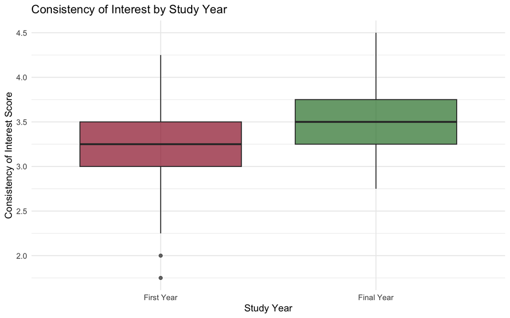

```r
# Create a boxplot for Consistency of Interest
#| 1. Set up plot with aesthetics (x = Study_Year, y = consistency_interest)
ggplot(grit_data, aes(x = factor(Study_Year), y = consistency_interest, fill = factor(Study_Year))) +
  #| 2. Add boxplot geometry
  geom_boxplot(alpha = 0.7) +
  #| 3. Customize labels and colors
  scale_x_discrete(labels = c("1" = "First Year", "2" = "Final Year")) +
  scale_fill_manual(values = c("#9B1B30", "#2E7D32"), guide = "none") +
  #| 4. Apply minimal theme
  theme_minimal() +
  #| 5. Add informative labels
  labs(
    title = "Consistency of Interest by Study Year",
    x = "Study Year",
    y = "Consistency of Interest Score"
  )
```

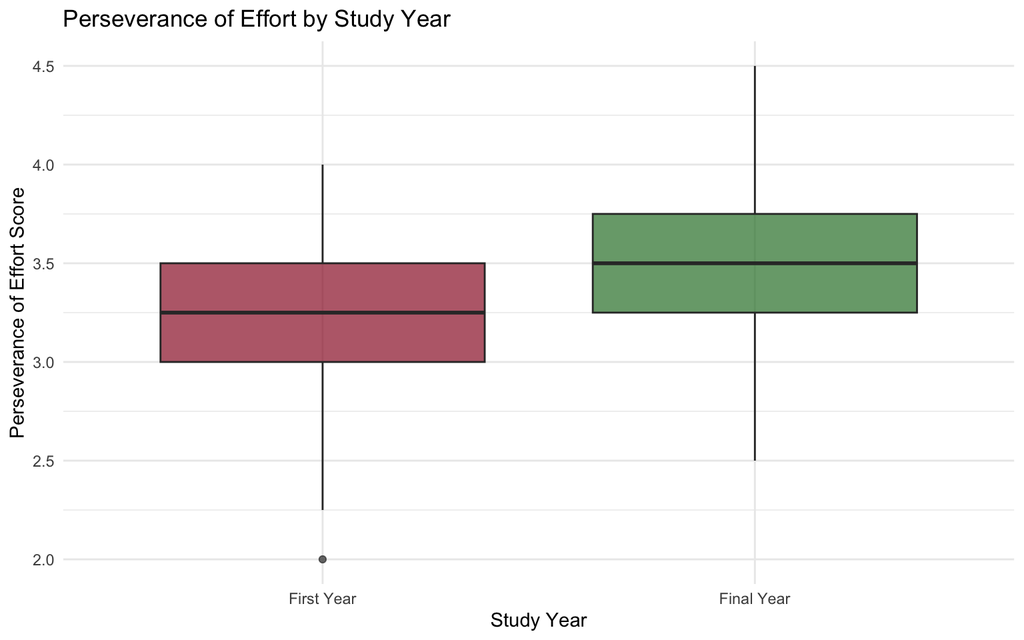

```r
# Create a boxplot for Perseverance of Effort
ggplot(grit_data, aes(x = factor(Study_Year), y = perseverance_effort, fill = factor(Study_Year))) +
  geom_boxplot(alpha = 0.7) +
  scale_x_discrete(labels = c("1" = "First Year", "2" = "Final Year")) +
  scale_fill_manual(values = c("#9B1B30", "#2E7D32"), guide = "none") +
  theme_minimal() +
  labs(
    title = "Perseverance of Effort by Study Year",
    x = "Study Year",
    y = "Perseverance of Effort Score"
  )
```

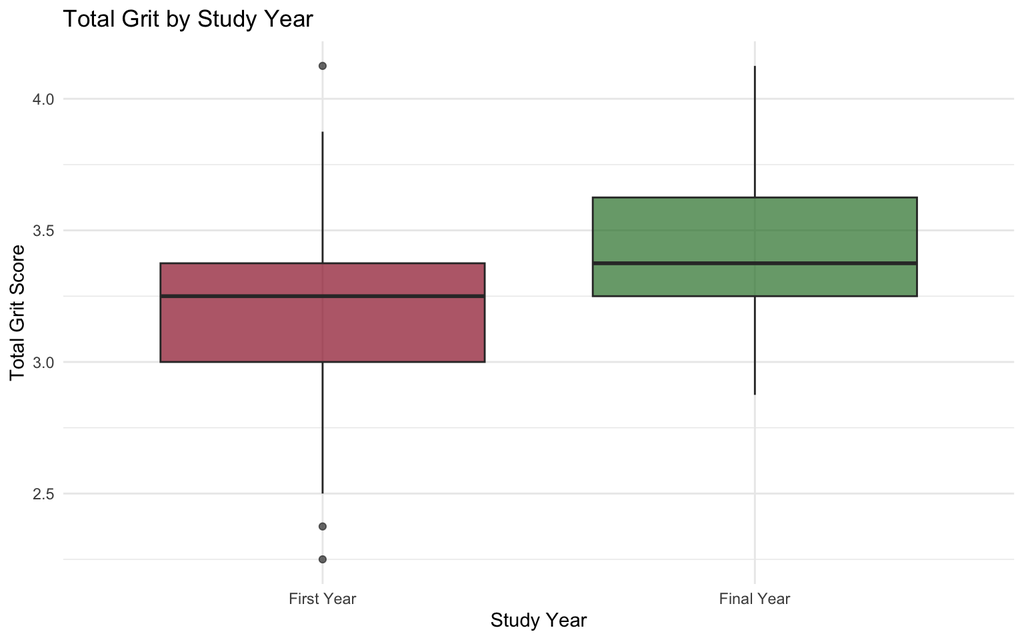

```r
# Create a boxplot for Total Grit
ggplot(grit_data, aes(x = factor(Study_Year), y = total_grit, fill = factor(Study_Year))) +
  geom_boxplot(alpha = 0.7) +
  scale_x_discrete(labels = c("1" = "First Year", "2" = "Final Year")) +
  scale_fill_manual(values = c("#9B1B30", "#2E7D32"), guide = "none") +
  theme_minimal() +
  labs(
    title = "Total Grit by Study Year",
    x = "Study Year",
    y = "Total Grit Score"
  )
```

**NoteExercise 4.2**

Describe what you see in the boxplots:

1. Do the groups appear similar or different for Consistency of Interest? **[YOUR ANSWER]**
2. Do the groups appear similar or different for Perseverance of Effort? **[YOUR ANSWER]**
3. Are there any outliers visible? **[YOUR ANSWER]**
4. Which subscale shows the largest difference between groups? **[YOUR ANSWER]**

# 7 Part 5: APA Write-Up and Development

**NoteSlides Part 5**

Complete this section during **Part 5: APA Write-Up** practice time.

## 7.1 Write Your Results Paragraph

**TipTemplate**

Participants reported [description] levels of grit overall. First-year students (M = *, SD =* , n = *) showed [description] compared to final-year students (M =* , SD = *, n =* ) on Consistency of Interest. For Perseverance of Effort, first-year students (M = *, SD =* ) [description] compared to final-year students (M = *, SD =* ). Overall grit scores were [description] for first-year students (M = *, SD =* ) compared to final-year students (M = *, SD =* ). These descriptive patterns suggest [your interpretation].

**YOUR WRITE-UP HERE:**

## 7.2 Proactive Coding Challenge

Now try creating your own analysis. You might:

- Calculate descriptives by Gender
- Create a combined plot showing both subscales
- Calculate the difference between subscales for each participant
- Explore the relationship between age and grit scores

```r
# YOUR CODE HERE
# Create your own analysis or visualization
# Be creative! What else might be interesting to explore?
```

**Describe what you did and what you found:**

## 7.3 Instructor Guidance: Scaffolding Ideas

**TipFor Instructors: Helping Students with Their Own Analysis**

If students are stuck, here are some scaffolded hints you can provide:

### 7.3.1 Option 1: Descriptives by Gender

**Hint 1:** Start by thinking about what you did for Study_Year. Can you do something similar?

**Hint 2:** Use `group_by()` with a different variable. What variable in the dataset represents gender?

**Hint 3:** The structure should be: `grit_data |> group_by(???) |> summarise(...)`

**If they’re still stuck:** Show them how to replace `Study_Year` with `Gender` in the grouped descriptives code from Part 4.

**TipOption 2: Side-by-Side Subscale Comparison**

**Hint 1:** You’ve already created separate boxplots for each subscale. Can you think of a way to show them together?

**Hint 2:** Try creating two boxplots side-by-side using `facet_wrap()` or by creating separate plots and arranging them.

**Hint 3:** You could also create two separate plots and compare them visually, or use `geom_boxplot()` twice in the same plot with different y-values.

**If they’re still stuck:** Guide them to create two separate boxplots (one for consistency, one for perseverance) and compare them side-by-side in the output.

**TipOption 3: Subscale Difference**

**Hint 1:** Think about what it means to calculate a “difference” between two scores for each person.

**Hint 2:** You can create a new column by subtracting one subscale from another. What’s the formula?

**Hint 3:** Once you have the difference, you could use `summary()` to see the distribution, or create a histogram with `geom_histogram()`.

**If they’re still stuck:** Show them: `grit_data$difference <- grit_data$perseverance_effort - grit_data$consistency_interest`, then help them visualize it.

**TipOption 4: Age and Grit Relationship**

**Hint 1:** To explore relationships, you need a scatterplot. What goes on the x-axis? What goes on the y-axis?

**Hint 2:** Use `geom_point()` for a scatterplot. What variables should you use for x and y?

**Hint 3:** You can add a trend line with `geom_smooth(method = "lm")` to see if there’s a pattern.

**Hint 4:** To quantify the relationship, use `cor()` to calculate a correlation coefficient.

**If they’re still stuck:** Guide them: `ggplot(grit_data, aes(x = Age, y = total_grit)) + geom_point()`

# 8 Reflection

**NoteExercise 5.1**

Answer these reflection questions:

1. **What was the most challenging part of this lab?**

[YOUR ANSWER]

2. **What would you do differently next time?**

[YOUR ANSWER]

3. **What questions do you still have?**

[YOUR ANSWER]

**ImportantSubmission Checklist**

Before submitting, ensure you have:

- Replaced “YOUR NAME HERE” with your name
- Completed all exercises (1.1, 2.1, 3.1, 3.2, 4.1, 4.2, 5.1)
- Written the APA results paragraph
- Created a proactive analysis or visualization
- Answered the reflection questions
- Rendered to HTML successfully